# Larvae Survivability Assays

Yva Eline

2024-10-24

## Introduction

To determine if the high degree of stocasticity observed in larval gut microbiota can be manipulated by the introduction of an adult gut specific bacteria. Honey bee (*Apis mellifera*) larvae were treated with some amount of *Lactobacillus spp and reared in laboratory conditions for a total of six days. Survivibility graphs were produced of the replicate experiments.

* spoiler - turns out it wasn’t Lactobacillus spp

## Reading in the data and adding a replicate column

```r
# Read data from each sheet & add a replicate column
rep1 <- read_excel("larvae_ncimb_lacto.xlsx", sheet = "replicate_1") %>% mutate(replicate = "Replicate 1")
rep2 <- read_excel("larvae_ncimb_lacto.xlsx", sheet = "replicate_2") %>% mutate(replicate = "Replicate 2")
rep3 <- read_excel("larvae_ncimb_lacto.xlsx", sheet = "replicate_3") %>% mutate(replicate = "Replicate 3")
rep4 <- read_excel("larvae_ncimb_lacto.xlsx", sheet = "replicate_4") %>% mutate(replicate = "Replicate 4")
```

## Combining & Manipulating the Datasheet

Here we combined the data into one dataframe and converted the treatment labels to uppercase for consistency

```r
# Combine data into one dataframe
combined_data <- bind_rows(rep1, rep2, rep3, rep4)

# Convert treatment labels to upper case
combined_data <- combined_data %>% mutate(treatment = toupper(treatment))
```

## Creating Individual Plots

We start by generating individual plots of each replicate to visualize the number of larvae alive over time for each treatment

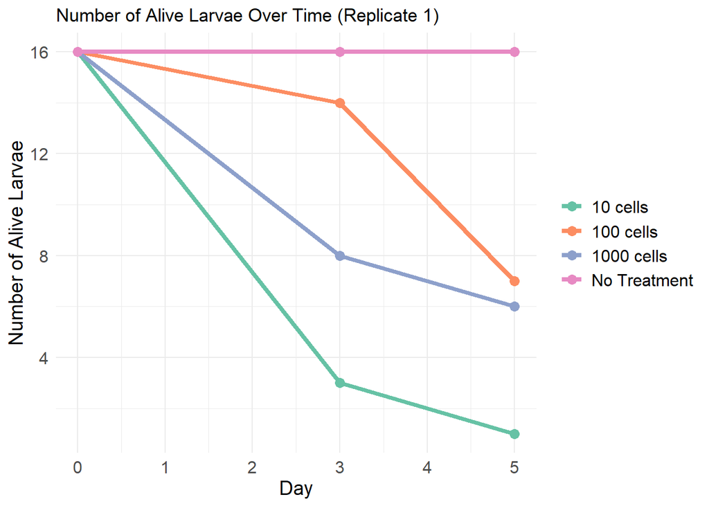

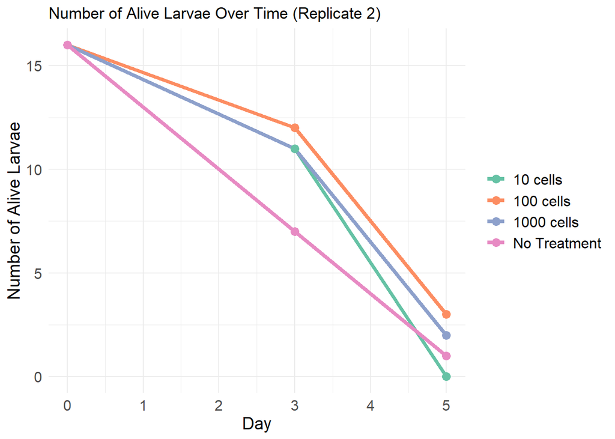

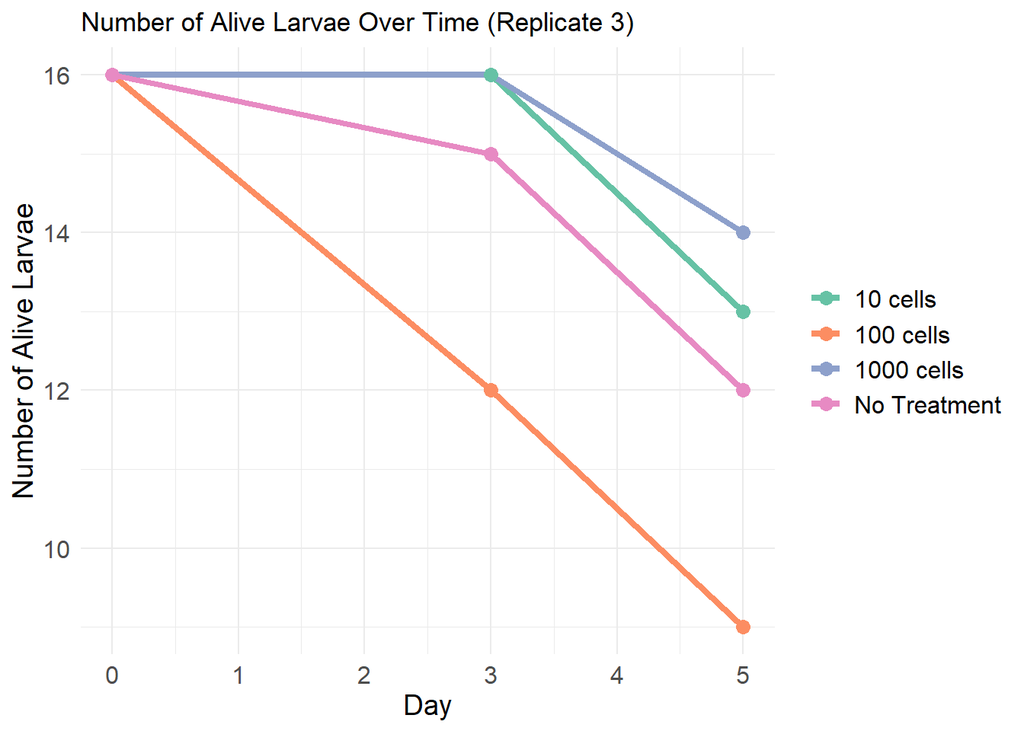

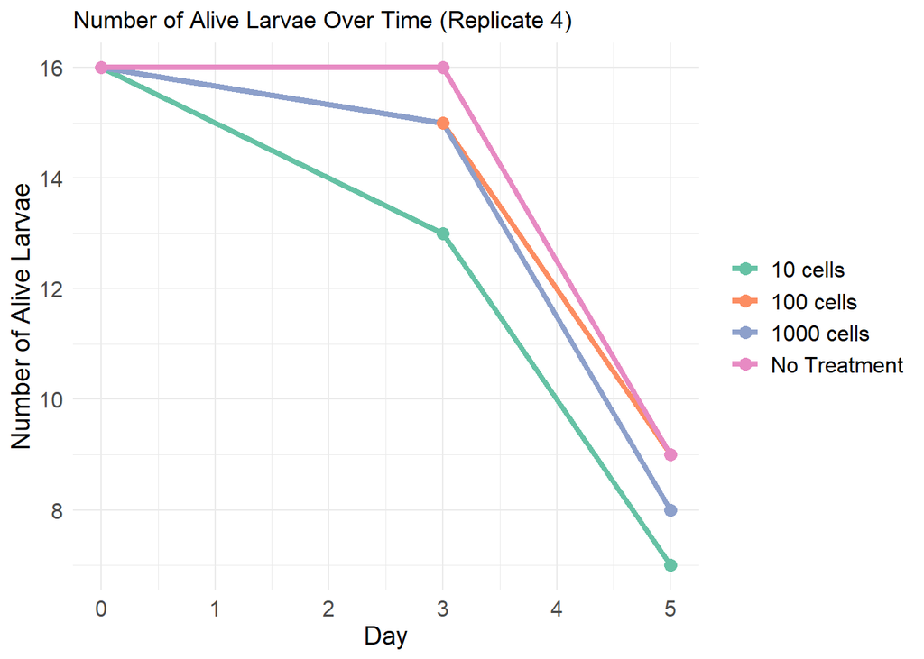

```r
# Individual replicates plot
palette <- brewer.pal(n = 4, name = "Set2")
replicates <- unique(combined_data$replicate)

for (rep in replicates) {
  replicate_data <- combined_data %>% filter(replicate == rep)

  p <- ggplot(replicate_data, aes(x = day, y = alive_count, color = treatment, group = treatment)) +
    geom_line(size = 1.5) +  # Thicker lines
    geom_point(size = 3) +  # Larger points
    labs(title = paste("Number of Alive Larvae Over Time (", rep, ")", sep = ""),
         x = "Day",
         y = "Number of Alive Larvae") +
    scale_color_manual(
      values = palette,
      labels = c("1000" = "1000 cells", "100" = "100 cells", "10" = "10 cells", "NT" = "No Treatment")
    ) +
    theme_minimal() +
    theme(
      legend.title = element_blank(),
      legend.text = element_text(size = 12), # Larger legend text
      axis.text = element_text(size = 12), # Larger axis text
      axis.title = element_text(size = 14), # Larger axis titles
      plot.background = element_rect(fill = "white", color = NA),  # Ensure white background
      panel.background = element_rect(fill = "white", color = NA)  # Ensure white background
    )

  # View the plot
  print(p)
}
```

## Summarizing the Data

Finally we summarize the data for each experimental replicate by calculating the mean and standard error for the number of larvae alive, grouped by treatment and day and visualize this in a combined plot.

```r
# Summarize data: calculate mean and standard error for alive larvae by treatment and day
summary_data <- combined_data %>%
  group_by(treatment, day) %>%
  summarize(
    mean_alive_count = mean(alive_count, na.rm = TRUE),
    se_alive_count = sd(alive_count, na.rm = TRUE) / sqrt(n())
  )
```

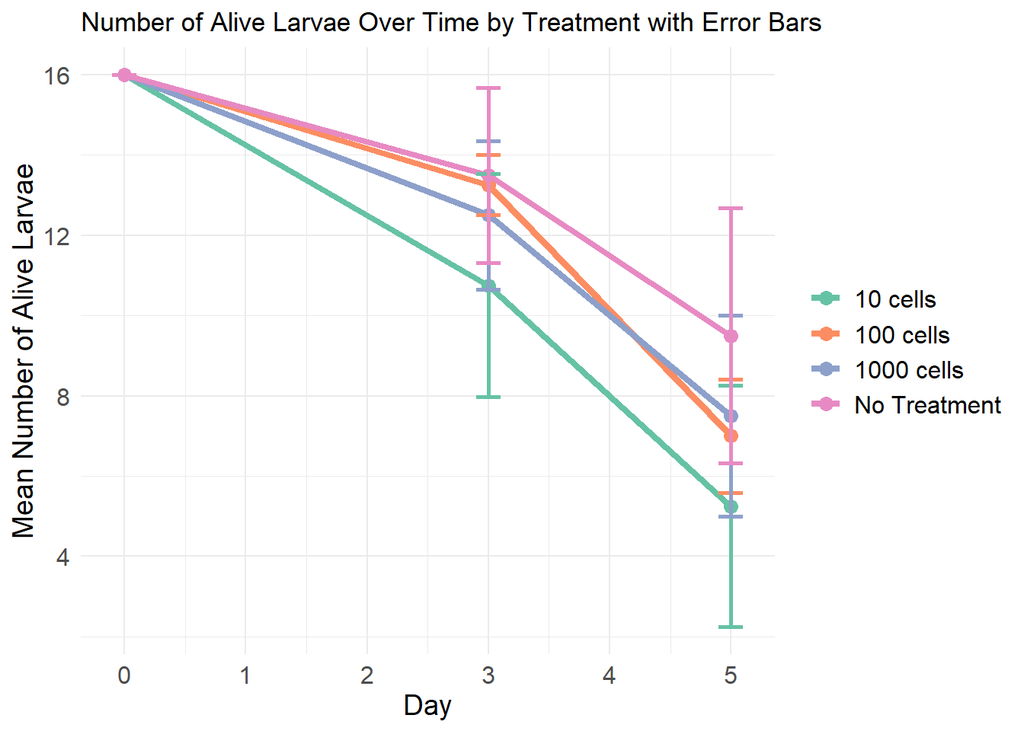

```r
# Combined plot with error bars
combined_plot <- ggplot(summary_data, aes(x = day, y = mean_alive_count, color = treatment, group = treatment)) +
  geom_line(size = 1.5) +  # Thicker lines
  geom_point(size = 3) +  # Larger points
  geom_errorbar(aes(ymin = mean_alive_count - se_alive_count, ymax = mean_alive_count + se_alive_count), width = 0.2, size = 1) + # Thicker error bars
  labs(title = "Number of Alive Larvae Over Time by Treatment with Error Bars",
       x = "Day",
       y = "Mean Number of Alive Larvae") +
  scale_color_manual(
    values = palette,
    labels = c("1000" = "1000 cells", "100" = "100 cells", "10" = "10 cells", "NT" = "No Treatment")
  ) +
  theme_minimal() +
  theme(
    legend.title = element_blank(),
    legend.text = element_text(size = 12), # Larger legend text
    axis.text = element_text(size = 12), # Larger axis text
    axis.title = element_text(size = 14), # Larger axis titles
    plot.background = element_rect(fill = "white", color = NA),  # Ensure white background
    panel.background = element_rect(fill = "white", color = NA)  # Ensure white background
  )

# View the plot
print(combined_plot)
```

```r
ggsave("combined_plot.png", plot = combined_plot, width = 8, height = 6, bg = "white")
```